# Tibbles

### 10.5 Exercises

1. How can you tell if an object is a tibble? (Hint: try printing `mtcars`, which is a regular data frame).

`# A tibble:` is displayed in the top left when printing the data frame. Additional information is printed, such as column types and total number of rows and columns.

2. Compare and contrast the following operations on a `data.frame` and equivalent tibble. What is different? Why might the default data frame behaviours cause you frustration?

```r
df <- data.frame(abc = 1, xyz = "a")
df$x
df[, "xyz"]
df[, c("abc", "xyz")]
```

[output not shown]

```r
df <- tibble(abc = 1, xyz = "a")
df$x
```

```r
df[, "xyz"]
```

```
## # A tibble: 1 x 1
##     xyz
##   <chr>
## 1     a
```

```r
df[, c("abc", "xyz")]
```

```
## # A tibble: 1 x 2
##     abc   xyz
##   <dbl> <chr>
## 1     1     a
```

The default data frame uses partial matching. In comparison, tibbles do not. By default, data frames also appear to store strings as factors (see `df[, "xyz"` and `df[, c("abc","xyz")]` output).

3. If you have the name of a variable stored in an object, e.g. `var <- "mpg"`, how can you extract the reference variable from a tibble?

By using the double bracket, `[[`. For example, `df[[var]]`.

4. Practice referring to non-syntactic names in the following data frame by:
   1. Extracting the variable called `1`.
   2. Plotting a scatterplot of `1` vs `2`.
   3. Creating a new column called `3` which is `2` divided by `1`.
   4. Renaming the columns to `one`, `two` and `three`.

   ```r
   annoying <- tibble(
     `1` = 1:10,
     `2` = `1` * 2 + rnorm(length(`1`))
   )
   ```

Extracting the variable called `1`:

```r
annoying$`1`
```

```
##  [1]  1  2  3  4  5  6  7  8  9 10
```

Plotting a scatterplot of `1` vs `2`:

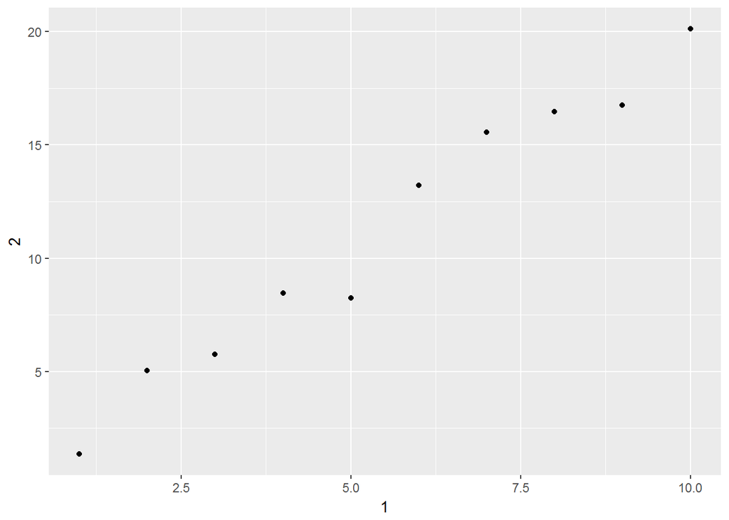

```r
ggplot(annoying, aes(`1`, `2`)) +
  geom_point()
```

Creating a new column called `3` which is `2` divided by `1`:

```r
annoying <- annoying %>%
  mutate(`3` = `2` / `1`)
```

Renaming the columns to `one`, `two` and `three`:

```r
annoying <- annoying %>%
  rename(`one` = `1`,
         `two` = `2`,
         `three` = `3`)
```

5. What does `tibble::enframe()` do? When might you use it?

It converts atomic vectors or lists to two-column data frames.

6. What option controls how many additional column names are printed at the footer of a tibble?

`n_extra` from `print.tbl()`. For example:

```r
print(flights, n_extra = 1)
```

```
## # A tibble: 336,776 x 19
##     year month   day dep_time sched_dep_time dep_delay arr_time
##    <int> <int> <int>    <int>          <int>     <dbl>    <int>
##  1  2013     1     1      517            515         2      830
##  2  2013     1     1      533            529         4      850
##  3  2013     1     1      542            540         2      923
##  4  2013     1     1      544            545        -1     1004
##  5  2013     1     1      554            600        -6      812
##  6  2013     1     1      554            558        -4      740
##  7  2013     1     1      555            600        -5      913
##  8  2013     1     1      557            600        -3      709
##  9  2013     1     1      557            600        -3      838
## 10  2013     1     1      558            600        -2      753
## # ... with 336,766 more rows, and 12 more variables: sched_arr_time <int>,
## #   ...
```